# Final Project 1

##### 1.3.3.1.3 Response vs. B

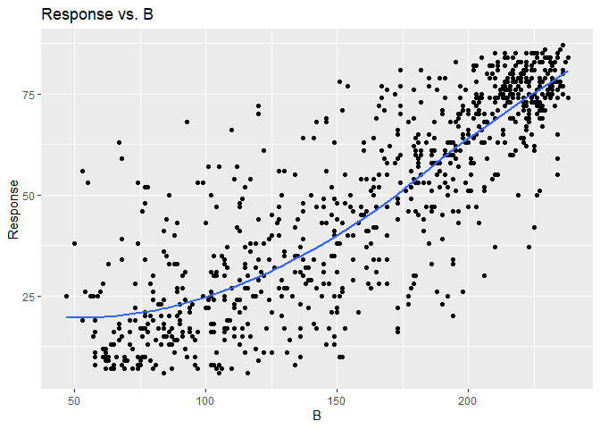

```r
df |>
  ggplot(aes(x = B, y = response)) +
  geom_point() +
  labs(title = "Response vs. B", x = "B", y = "Response") +
  geom_smooth(method = 'loess',formula = 'y ~ x', se = FALSE)
```

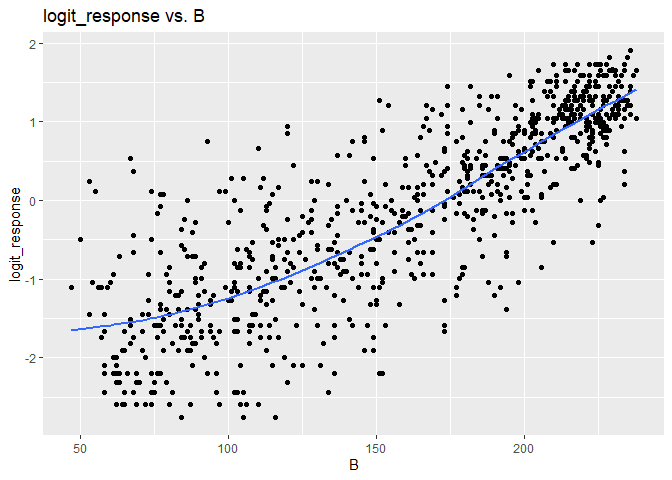

```r
df |>
  ggplot(aes(x = B, y = logit_response)) +
  geom_point() +
  labs(title = "logit_response vs. B", x = "B", y = "logit_response") +
  geom_smooth(method = 'loess',formula = 'y ~ x', se = FALSE)
```

Both the response and the logit response variables are correlated with B. The response variable increases as B increases.

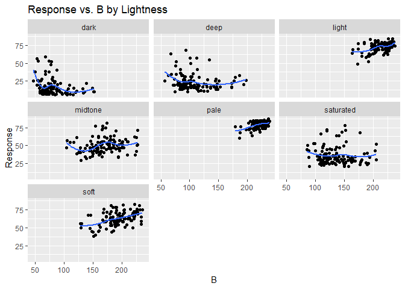

```r
df |>
  ggplot(aes(x = B, y = response)) +
  geom_point() +
  labs(title = "Response vs. B by Lightness", x = "B", y = "Response") +
  geom_smooth(method = 'loess',formula = 'y ~ x', se = FALSE) +
  facet_wrap(~ Lightness)
```

Based on the shown plot, the response variable relationship with B by Lightness is complicated and don’t seem linear as it directly is with B!

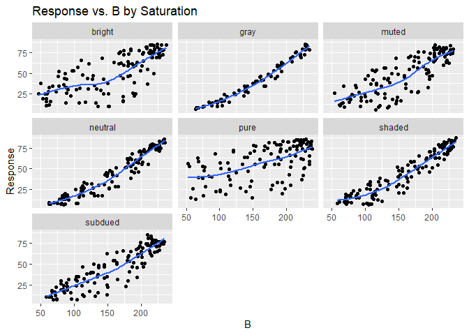

```r
df |>
  ggplot(aes(x = B, y = response)) +
  geom_point() +
  labs(title = "Response vs. B by Saturation", x = "B", y = "Response") +
  geom_smooth(method = 'loess',formula = 'y ~ x', se = FALSE) +
  facet_wrap(~ Saturation)
```

Based on the shown plot, the response variable increases as B increases for all saturation categories. The relationship seems to be linear for all the categories except for pureand bright, it’s hard to tell.

##### 1.3.3.1.4 Response vs. Hue

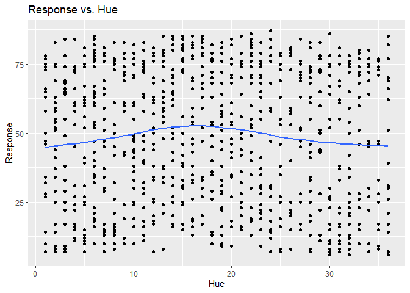

```r
df |>
  ggplot(aes(x = Hue, y = response)) +
  geom_point() +
  labs(title = "Response vs. Hue", x = "Hue", y = "Response") +
  geom_smooth(method = 'loess',formula = 'y ~ x', se = FALSE)
```

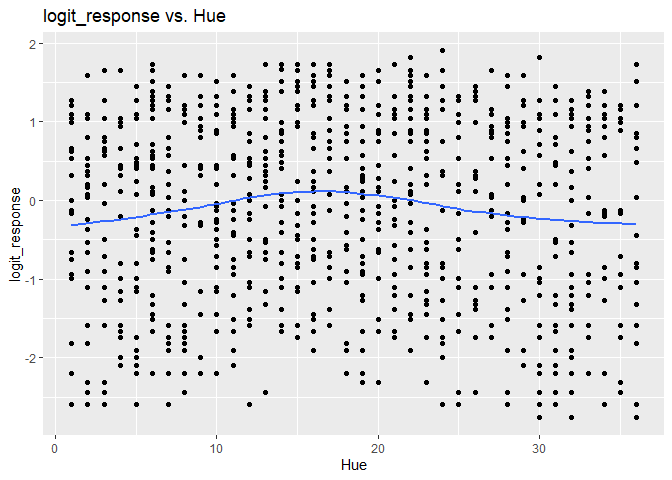

```r
df |>
  ggplot(aes(x = Hue, y = logit_response)) +
  geom_point() +
  labs(title = "logit_response vs. Hue", x = "Hue", y = "logit_response") +
  geom_smooth(method = 'loess',formula = 'y ~ x', se = FALSE)
```

Both the response and the logit response variables are not correlated with Hue based on the direct relationship between them.

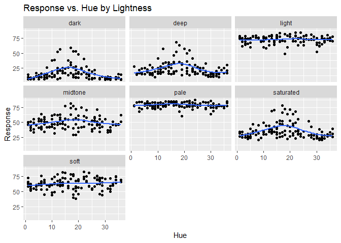

```r
df |>
  ggplot(aes(x = Hue, y = response)) +
  geom_point() +
  labs(title = "Response vs. Hue by Lightness", x = "Hue", y = "Response") +
  geom_smooth(method = 'loess',formula = 'y ~ x', se = FALSE) +
  facet_wrap(~ Lightness)
```

Based on the shown plot, we can now see kind of constant response values for all lightness categories. For instance the response values are very high for the light and pale categories and very low for the dark and deep categories. On the other hand, the response values for midtone and saturated are spread around.

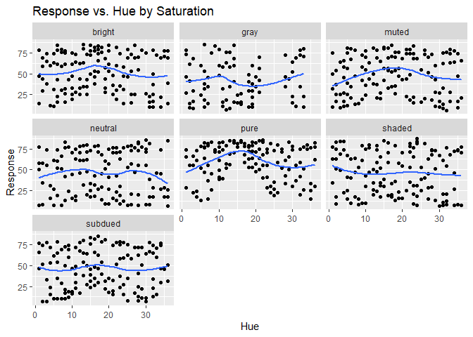

```r
df |>
  ggplot(aes(x = Hue, y = response)) +
  geom_point() +
  labs(title = "Response vs. Hue by Saturation", x = "Hue", y = "Response") +
  geom_smooth(method = 'loess',formula = 'y ~ x', se = FALSE) +
  facet_wrap(~ Saturation)
```

Based on the shown plot, the response variable exhibits a complex relationship with all saturation categories.

### 1.3.4 Binary outcome vs. R, G, B and Hue

##### 1.3.4.0.1 Binary outcome vs. R

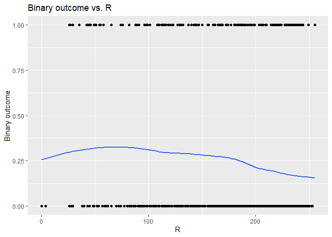

```r
df |>
  ggplot(aes(x = R, y = outcome)) +
  geom_point() +
  labs(title = "Binary outcome vs. R", x = "R", y = "Binary outcome") +
  geom_smooth(method = 'loess',formula = 'y ~ x', se = FALSE)
```

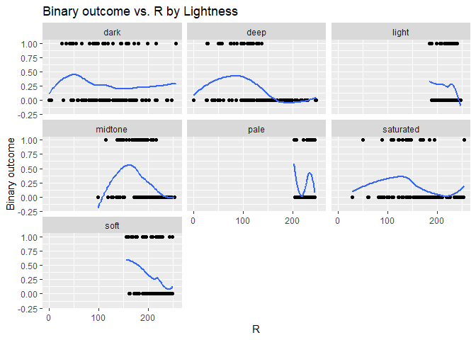

```r
df |>
  ggplot(aes(x = R, y = outcome)) +
  geom_point() +
  labs(title = "Binary outcome vs. R by Lightness", x = "R", y = "Binary outcome") +
  geom_smooth(method = 'loess',formula = 'y ~ x', se = FALSE) +
  facet_wrap(~ Lightness)
```

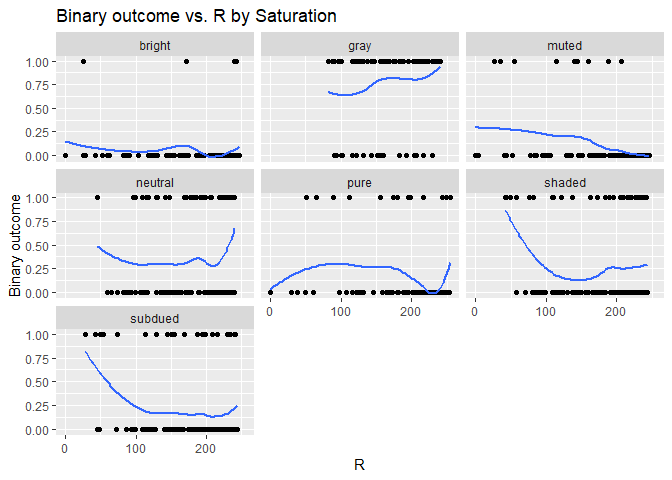

```r
df |>
  ggplot(aes(x = R, y = outcome)) +
  geom_point() +
  labs(title = "Binary outcome vs. R by Saturation", x = "R", y = "Binary outcome") +
  geom_smooth(method = 'loess',formula = 'y ~ x', se = FALSE) +
  facet_wrap(~ Saturation)
```

##### 1.3.4.0.2 Binary outcome vs. G

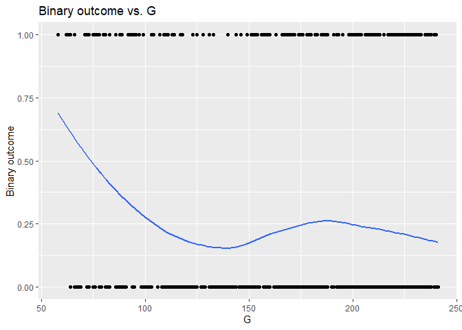

```r
df |>
  ggplot(aes(x = G, y = outcome)) +
  geom_point() +
  labs(title = "Binary outcome vs. G", x = "G", y = "Binary outcome") +
  geom_smooth(method = 'loess',formula = 'y ~ x', se = FALSE)
```

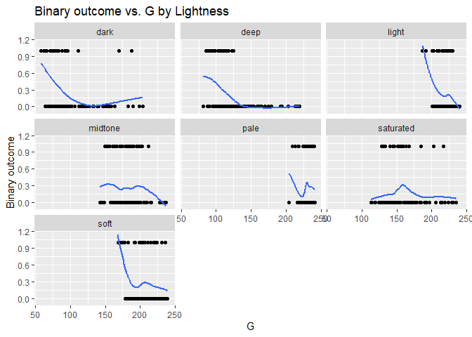

```r
df |>
  ggplot(aes(x = G, y = outcome)) +
  geom_point() +
  labs(title = "Binary outcome vs. G by Lightness", x = "G", y = "Binary outcome") +
  geom_smooth(method = 'loess',formula = 'y ~ x', se = FALSE) +
  facet_wrap(~ Lightness)
```

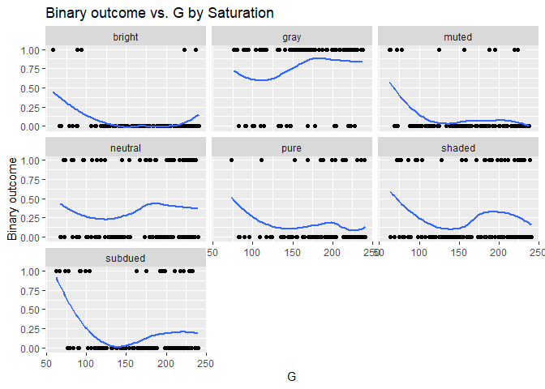

```r
df |>
  ggplot(aes(x = G, y = outcome)) +
  geom_point() +
  labs(title = "Binary outcome vs. G by Saturation", x = "G", y = "Binary outcome") +
  geom_smooth(method = 'loess',formula = 'y ~ x', se = FALSE) +
  facet_wrap(~ Saturation)
```

##### 1.3.4.0.3 Binary outcome vs. B

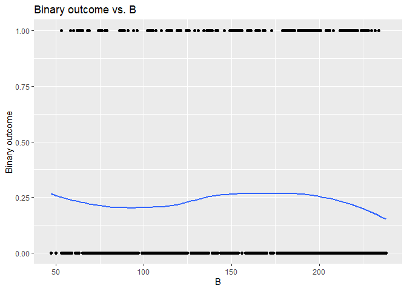

```r
df |>
  ggplot(aes(x = B, y = outcome)) +
  geom_point() +
  labs(title = "Binary outcome vs. B", x = "B", y = "Binary outcome") +
  geom_smooth(method = 'loess',formula = 'y ~ x', se = FALSE)
```

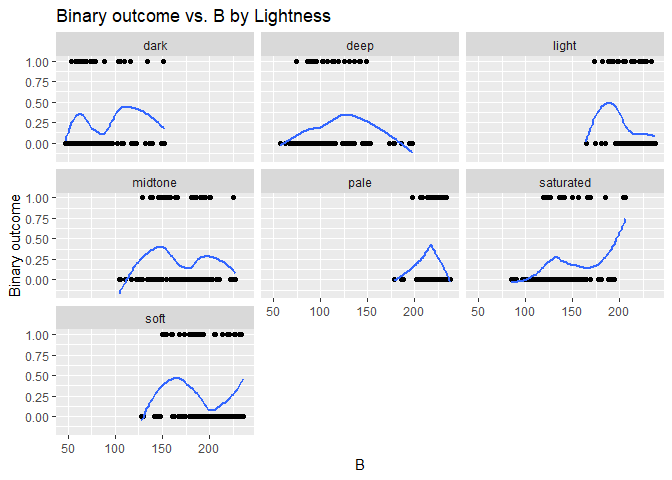

```r
df |>
  ggplot(aes(x = B, y = outcome)) +
  geom_point() +
  labs(title = "Binary outcome vs. B by Lightness", x = "B", y = "Binary outcome") +
  geom_smooth(method = 'loess',formula = 'y ~ x', se = FALSE) +
  facet_wrap(~ Lightness)
```

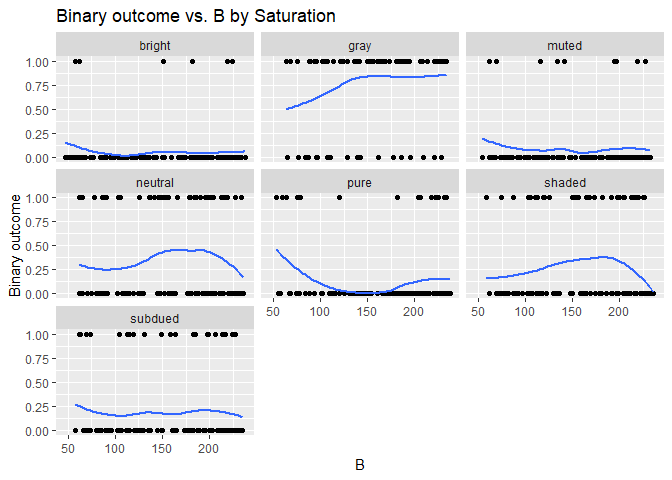

```r
df |>
  ggplot(aes(x = B, y = outcome)) +
  geom_point() +
  labs(title = "Binary outcome vs. B by Saturation", x = "B", y = "Binary outcome") +
  geom_smooth(method = 'loess',formula = 'y ~ x', se = FALSE) +
  facet_wrap(~ Saturation)
```

##### 1.3.4.0.4 Binary outcome vs. Hue

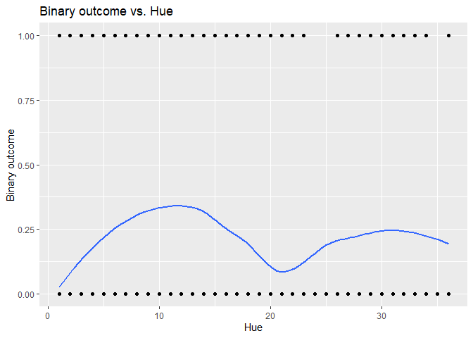

```r
df |>
  ggplot(aes(x = Hue, y = outcome)) +
  geom_point() +
  labs(title = "Binary outcome vs. Hue", x = "Hue", y = "Binary outcome") +
  geom_smooth(method = 'loess',formula = 'y ~ x', se = FALSE)
```

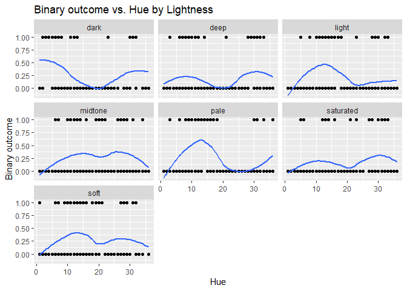

```r
df |>
  ggplot(aes(x = Hue, y = outcome)) +
  geom_point() +
  labs(title = "Binary outcome vs. Hue by Lightness", x = "Hue", y = "Binary outcome") +
  geom_smooth(method = 'loess',formula = 'y ~ x', se = FALSE) +
  facet_wrap(~ Lightness)
```

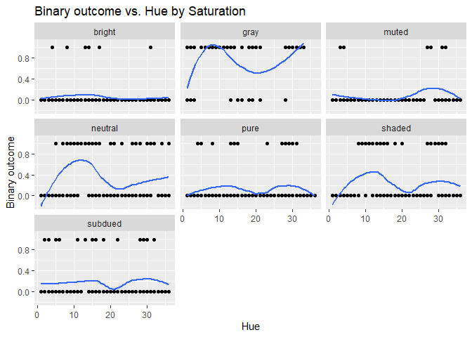

```r
df |>
  ggplot(aes(x = Hue, y = outcome)) +
  geom_point() +
  labs(title = "Binary outcome vs. Hue by Saturation", x = "Hue", y = "Binary outcome") +
  geom_smooth(method = 'loess',formula = 'y ~ x', se = FALSE) +
  facet_wrap(~ Saturation)
```

### 1.3.5 Binary outcome vs. categorical variables

##### 1.3.5.0.1 Binary outcome vs. Lightness

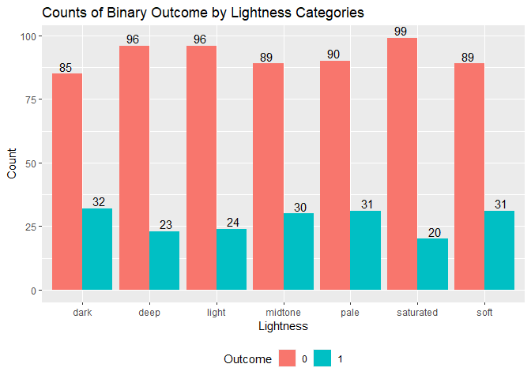

```r
df %>%
    group_by(Lightness, outcome) %>%
    summarize(Count = n()) %>%
    ggplot(aes(x = Lightness, y = Count, fill = as.factor(outcome))) +
        geom_bar(stat = "identity", position = "dodge") +
        labs(title = "Counts of Binary Outcome by Lightness Categories", x = "Lightness", y = "Count") +
        scale_fill_discrete(name = "Outcome") +
        theme(legend.position = "bottom") +
  geom_text(aes(label = Count), vjust = -0.3, position = position_dodge(width = 1))
```

##### 1.3.5.0.2 Binary outcome vs. Saturation

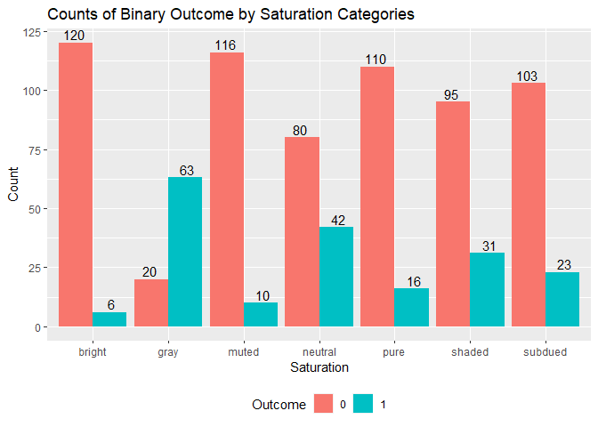

```r
df %>%
    group_by(Saturation, outcome) %>%
    summarize(Count = n()) %>%
    ggplot(aes(x = Saturation, y = Count, fill = as.factor(outcome))) +
        geom_bar(stat = "identity", position = "dodge") +
        labs(title = "Counts of Binary Outcome by Saturation Categories", x = "Saturation", y = "Count") +
        scale_fill_discrete(name = "Outcome") +
        theme(legend.position = "bottom") +
  geom_text(aes(label = Count), vjust = -0.3, position = position_dodge(width = 1))
```